# Testing a diseased cohort against a Bayesian healthy atlas

From the ZINB baseline to a non-parametric biomarker test on the mean parameter μ

Author

Affiliation

Chen Zhan

SAiGENCI, The University of Adelaide

Published

12 Jun 2026

```r
suppressMessages({
  library(SummarizedExperiment)
  library(edgeR)
  library(tidybulk)
  library(dplyr)
  library(tidyverse)
  library(knitr)
})

# Cached objects (built once; see mu_test_build_env.R / mu_test_epred_baseline.R)
se_cache           <- "/home/a1237163/mu_test_se_monocytic.rds"
epred_baseline_rds <- "/home/a1237163/mu_test_epred_baseline.rds"
data_dir           <- "/home/a1237163/lab/chen/posteriorHCA/dev/SAVI/data"
baseline_draws_rds <- file.path(data_dir, "SAVI_gene_baseline_draws_universal.rds")

gene_id <- "ENSG00000196428"          # TSC22D2

.c              <- readRDS(se_cache)
se_monocytic    <- .c$se_monocytic
ref_sample_name <- .c$ref_sample_name

# Human-readable table formatting (avoid scientific notation in kable).
fmt_num <- function(x, digits = 3) {
  format(round(x, digits), nsmall = digits, trim = TRUE, scientific = FALSE)
}
fmt_int <- function(x) format(as.integer(x), big.mark = ",", scientific = FALSE, trim = TRUE)
```

# The question

We have a Bayesian model of “healthy” gene expression built from a large single-cell atlas, and a small diseased cohort of our own — **SAVI** (STING-associated vasculopathy with onset in infancy), a handful of donors, sequenced as disease-associated monocytes, together with a matched **CTRL** group.

For a candidate biomarker gene we want to answer a deceptively simple question:

> Is the gene’s expression in the SAVI cohort **significantly different** from what the healthy atlas says it should be?

The difficulty is that the two sides come from completely different statistical machinery: a Bayesian **zero-inflated negative binomial (ZINB)** mixed model for the atlas, and a frequentist **edgeR negative-binomial GLM** for our cohort. To compare them we must (i) extract a quantity that means the *same thing* in both models, and (ii) make sure it is reported on the *same scale*. This report tells that story and documents the verification we did along the way.

# The healthy baseline: a Bayesian ZINB atlas model

Each gene in the atlas is modelled with `brms` as a zero-inflated negative binomial regression on the raw counts, with a per-sample **offset** and a rich fixed/random-effect structure:

```r
# (exposition only — the fit is reconstructed from a compressed store; see below)
formula <- bf(
  counts ~ 1 + offset(offset) +
    age_decade * sex + disease_groups_altered + ethnicity_groups + assay_groups_altered +
    (1 | dataset_id_altered) +
    (1 + age_decade * sex + ethnicity_groups | <finer grouping>),
  shape  ~ 1 + disease_groups_altered + assay_groups_altered + ethnicity_groups +
    (1 | tissue_groups)
)
brm(formula, data = data, family = zero_inflated_negbinomial())
```

The negative-binomial **mean parameter** for sample $j$ is

$$\log \mu_j \;=\; \underbrace{\text{offset}_j}_{\text{sequencing depth}} \;+\; \mathbf{x}_j^\top \boldsymbol\beta ,$$

and the observed count is then $y_j \sim \text{ZINB}(\mu_j, \phi, \pi)$, i.e. with probability $\pi$ a structural zero and otherwise $\text{NB}(\mu_j, \phi)$.

## What the offset is

The offset is the **log effective library size**. In training it is defined from `tidybulk::scale_abundance`:

## The universal (marginal) baseline

Our cohort’s metadata (age, sex, ethnicity, assay) is largely **unknown**. So instead of conditioning the baseline on specific covariates, we build a **universal** baseline: we hold the biologically required terms fixed (`disease = Normal`, `tissue = blood`, `offset = 0`), and **marginalise** over the unknown covariates by averaging the prediction over the full grid of their atlas levels. This yields, per gene, a large pool of posterior draws of $\log\mu$ that represents “healthy expression across all plausible covariate combinations”.

# What “μ” means — and why `posterior_linpred`, not `posterior_epred`

This is the first subtlety. For a **zero-inflated** NB model the two obvious `brms` extractors give different things:

| extractor | returns | meaning |
| --- | --- | --- |
| `posterior_epred()` | $(1-\pi)\,\mu$ | expected **count** (zero-inflation folded in) |
| `posterior_linpred(transform = FALSE)` | $\log\mu$ | the NB **location parameter** (log scale) |

We want the **NB mean parameter $\mu$** — the biological expression level *before* the zero-inflation machinery — because that is the quantity edgeR’s NB GLM also estimates. So the baseline draws are produced with `posterior_linpred(transform = FALSE)` and then exponentiated, **not** `posterior_epred`.

```r
# How the baseline draws were generated (mu_test_epred_baseline.R).
log_mu_mat <- posterior_linpred(
  fit, newdata = nd_grid, transform = FALSE,   # log(mu), NOT epred
  re_formula = NULL, allow_new_levels = TRUE, sample_new_levels = "gaussian"
)
log_mu           <- as.numeric(log_mu_mat)   # pooled draws x grid (full spread)
grand_mean_draws <- rowMeans(log_mu_mat)     # per-draw average over the grid (see §[SE](#sec-se))
```

```r
ep <- readRDS(epred_baseline_rds)
baseline_summary <- tibble::tibble(
  quantity = c("median μ (count scale)",
               "mean log(μ)",
               "SD log(μ) — full predictive spread",
               "SD of grand-mean draws — uncertainty in the mean",
               "n pooled draws", "n posterior draws (grand mean)"),
  value = c(fmt_num(ep$median_mu, 1),
            fmt_num(ep$mean_log_mu, 3),
            fmt_num(ep$sd_log_mu, 3),
            fmt_num(ep$sd_grand_mean, 3),
            fmt_int(ep$n_draws),
            fmt_int(ep$n_grand))
)
kable(baseline_summary, caption = "Healthy baseline μ for TSC22D2 (universal marginal).")
```

Healthy baseline μ for TSC22D2 (universal marginal).

| quantity | value |
| --- | --- |
| median μ (count scale) | 159.9 |
| mean log(μ) | 5.128 |
| SD log(μ) — full predictive spread | 1.776 |
| SD of grand-mean draws — uncertainty in the mean | 0.715 |
| n pooled draws | 336,000 |
| n posterior draws (grand mean) | 400 |

## Baseline distributions on the log(μ) scale

Both baseline summaries live on the **log(μ) scale** because that is what `posterior_linpred(transform = FALSE)` returns — the NB location parameter before exponentiation. We expect both distributions to be **approximately normal**, for slightly different reasons:

- **Full marginal log(μ) draws** (`log_mu`, pooled over posterior draws × covariate grid). Each draw is the linear predictor $\log\mu = \text{offset} + \mathbf{x}^\top\boldsymbol\beta + \text{random effects}$. That is a sum of many fixed and random components. Even though we marginalise over a discrete covariate grid (a mixture), the resulting cloud is bell-shaped: most mass sits near the typical healthy state, with heavier tails from rare covariate combinations (young vs senior, different ethnicities, etc.).
- **Grand-mean log(μ) draws** (`grand_mean_draws`, one value per posterior draw). For each draw we average log(μ) over the full covariate grid. By the **central limit theorem**, averaging $G$ grid points shrinks the variance by roughly $1/G$ and pushes the distribution toward **Normality** much more tightly than the full marginal cloud. That is exactly why its SD (0.715) is less than half the full predictive SD (1.776): we are looking at uncertainty in the **mean**, not spread across conditions.

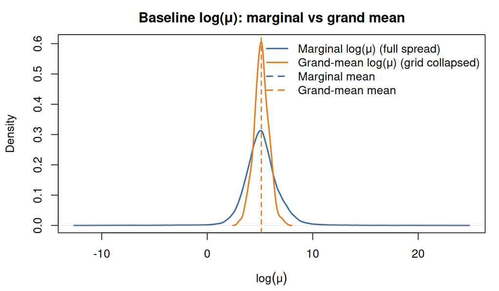

Baseline log(μ): full marginal spread (blue) vs posterior of the grand mean (orange). The grand-mean distribution is narrower and more Gaussian because each value averages over the covariate grid.

```r
par(mar = c(4.2, 4.2, 2.5, 1))
dens_marg <- density(ep$log_mu, na.rm = TRUE)
dens_mean <- density(ep$grand_mean_draws, na.rm = TRUE)
ylim <- range(c(dens_marg$y, dens_mean$y))
plot(dens_marg, col = "#3b6ea5", lwd = 2, ylim = ylim,
     main = "Baseline log(μ): marginal vs grand mean",
     xlab = expression(log(mu)), ylab = "Density")
lines(dens_mean, col = "#e67e22", lwd = 2)
abline(v = ep$mean_log_mu, col = "#3b6ea5", lty = 2, lwd = 1.5)
abline(v = ep$mean_grand_mean, col = "#e67e22", lty = 2, lwd = 1.5)
legend("topright", bty = "n", lwd = 2, lty = c(1, 1, 2, 2),
       col = c("#3b6ea5", "#e67e22", "#3b6ea5", "#e67e22"),
       legend = c("Marginal log(μ) (full spread)",
                  "Grand-mean log(μ) (grid collapsed)",
                  "Marginal mean", "Grand-mean mean"))
```

# The cohort: an edgeR negative-binomial model

For our own samples we use the standard edgeR NB-GLM workflow, with a **group-means design** `~ 0 + group` so that each group (SAVI, CTRL, reference) gets its own coefficient = $\log\mu$ at offset 0, rather than a fold change relative to a reference.

The crucial alignment step: we set edgeR’s offset to the **same** `scale_abundance` definition the ZINB was trained with, anchored to the **same** reference sample. Then “offset 0” means the same thing on both sides.

```r
se_test <- se_monocytic |>
  tidybulk::scale_abundance(method = "TMMwsp", reference_sample = ref_sample_name)

counts     <- assay(se_test, "counts")
meta       <- as.data.frame(colData(se_test))
offset_vec <- log(1 / meta$multiplier)                 # = training definition

group <- as.character(meta$Category); group[is.na(group)] <- "reference"
meta$group <- factor(group) |> fct_relevel("reference")

dge <- DGEList(counts = counts, samples = meta,
               genes = as.data.frame(rowData(se_test)))
reference <- which(colnames(dge$counts) == ref_sample_name)
dge$offset <- matrix(offset_vec, nrow(dge), ncol(dge), byrow = TRUE)

design <- model.matrix(~ 0 + group, data = meta)
colnames(design) <- sub("^group", "", colnames(design))

dge <- estimateDisp(dge, design)
fit <- glmQLFit(dge, design)
gi  <- match(gene_id, rownames(fit))

# Same dispersion mu_test.R uses (trended, falling back as needed).
nb_dispersion <- if (!is.null(dge$trended.dispersion)) {
  dge$trended.dispersion
} else if (!is.null(dge$tagwise.dispersion)) {
  dge$tagwise.dispersion
} else {
  rep_len(dge$common.dispersion, nrow(dge))
}
disp <- nb_dispersion[gi]
```

# Are the two offsets the same thing?

Both models use exactly the same equation, $\log\mu_j = \text{offset}_j + \mathbf{x}_j^\top\boldsymbol\beta$, with $\mu$ on the **raw count scale** and $\exp(\text{offset})$ the per-sample size factor. So conceptually the offset plays an identical role. But we should verify that edgeR’s normalisation and the training `scale_abundance` normalisation are the same numerically. We compared edgeR’s default offset ($\log(\text{lib.size}\times\text{norm.factor})$ from `calcNormFactors`) against `scale_abundance`’s $\log(1/\text{multiplier})$:

```r
A <- DGEList(counts = counts, samples = meta)
A <- calcNormFactors(A, refColumn = reference, method = "TMMwsp")
off_calcNF  <- log(A$samples$lib.size * A$samples$norm.factors)   # edgeR default
off_scaleAb <- offset_vec                                         # scale_abundance

offset_check <- tibble::tibble(
  metric = c("correlation(off1, off2)",
             "off1 - off2 : mean (the global constant)",
             "off1 - off2 : SD (0 => perfectly parallel)"),
  value  = c(round(cor(off_calcNF, off_scaleAb), 6),
             round(mean(off_calcNF - off_scaleAb), 4),
             signif(sd(off_calcNF - off_scaleAb), 3))
)
kable(offset_check, caption = "The two offsets are identical up to a global constant.")
```

The two offsets are identical up to a global constant.

| metric | value |
| --- | --- |
| correlation(off1, off2) | 1.0000 |
| off1 - off2 : mean (the global constant) | 15.1348 |
| off1 - off2 : SD (0 => perfectly parallel) | 0.0000 |

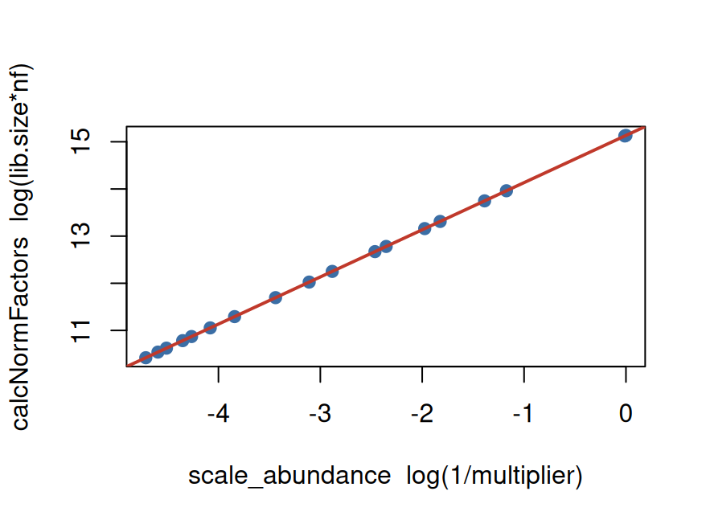

calcNormFactors vs scale_abundance offsets: a perfect line. They are the same normalisation; scale_abundance simply re-anchors the reference sample to 0.

```r
plot(off_scaleAb, off_calcNF, pch = 19, col = "#3b6ea5",
     xlab = "scale_abundance  log(1/multiplier)",
     ylab = "calcNormFactors  log(lib.size*nf)")
abline(a = mean(off_calcNF - off_scaleAb), b = 1, col = "#c0392b", lwd = 2)
```

**Conclusion.** The offset is the same quantity in the brms ZINB model and the edgeR NB model, and the two normalisation routines produce the same factors (correlation 1, differing only by a constant). We use `scale_abundance` solely because it re-anchors the reference sample to offset 0 — matching the brms training convention so that both sides report μ “at offset 0”.

# The pitfall: edgeR’s coefficient is *not* μ at offset 0

It is tempting to read the cohort’s $\log\mu$ straight off `fit$coefficients[gene, group]` (since offset 0 is the reference scale). **This is wrong**, and finding out why was the key discovery.

edgeR’s DGEList pipeline (`glmFit`/`glmQLFit`) internally **rescales a supplied offset by a constant**. As a result its coefficients are shifted on the *absolute* scale. The shift cancels in any group-vs-group contrast — edgeR’s intended use — so nobody normally notices. But we are comparing an **absolute** μ to an external baseline, where the shift does *not* cancel.

We verified the true NB mean three independent ways:

```r
sav <- which(meta$group == "SAVI")
ctl <- which(meta$group == "CTRL")

nb_mle <- function(j) {
  # genuine NB MLE of log(mu) at offset 0, offset applied directly
  edgeR::mglmOneGroup(matrix(counts[gi, j], nrow = 1),
                      dispersion = disp, offset = offset_vec[j])
}
glm_nb <- function(j) {
  unname(coef(glm(counts[gi, j] ~ 1 + offset(offset_vec[j]),
                  family = MASS::negative.binomial(theta = 1/disp)))[1])
}

verify <- tibble::tibble(
  estimator = c("edgeR glmQLFit coefficient (the trap)",
                "edgeR mglmOneGroup (raw NB MLE)",
                "independent MASS::glm.nb"),
  SAVI_logmu = c(fit$coefficients[gi, "SAVI"], nb_mle(sav), glm_nb(sav)),
  SAVI_mu    = exp(c(fit$coefficients[gi, "SAVI"], nb_mle(sav), glm_nb(sav))),
  CTRL_logmu = c(fit$coefficients[gi, "CTRL"], nb_mle(ctl), glm_nb(ctl))
) |>
  mutate(across(where(is.numeric), ~round(.x, 3)))
kable(verify, caption = "glmQLFit's coefficient is shifted by a constant (~0.85 here) for BOTH groups; the raw NB MLE is the correct μ at offset 0.")
```

glmQLFit’s coefficient is shifted by a constant (~0.85 here) for BOTH groups; the raw NB MLE is the correct μ at offset 0.

| estimator | SAVI_logmu | SAVI_mu | CTRL_logmu |
| --- | --- | --- | --- |
| edgeR glmQLFit coefficient (the trap) | 6.392 | 596.976 | 4.657 |
| edgeR mglmOneGroup (raw NB MLE) | 7.262 | 1425.419 | 5.525 |
| independent MASS::glm.nb | 7.262 | 1425.413 | 5.525 |

The `glmQLFit` coefficient understates SAVI’s μ by a factor of roughly $\exp(0.85)\approx 2.4\times$ — a constant shift visible in **both** groups (so it would vanish in a SAVI-vs-CTRL contrast, but it badly distorts the comparison to the healthy baseline).

**Fix.** Take the **point estimate** from the raw NB MLE (`mglmOneGroup`, offset applied directly), and use `glmQLFit` only for the **QL-shrunk Wald SE**, which is invariant to a constant offset shift. This is exactly what `mu_test.R` now does:

```r
ql_se <- function(grp) {
  mu_all <- fit$fitted.values[gi, ]
  W      <- mu_all / (1 + disp * mu_all)              # NB IRLS working weights
  cov_un <- solve(t(fit$design) %*% (W * fit$design))
  sqrt(fit$s2.post[gi] * cov_un[grp, grp])
}

mu_comparison <- tibble::tribble(
  ~source, ~group, ~`log(μ)`, ~`μ @ offset 0`, ~`SE / spread`,
  "Baseline (marginal)", "Healthy atlas",
    ep$mean_log_mu, ep$median_mu, ep$sd_log_mu,
  "Baseline (grand mean)", "Healthy atlas",
    ep$mean_grand_mean, exp(ep$mean_grand_mean), ep$sd_grand_mean,
  "Cohort (edgeR NB MLE)", "SAVI",
    nb_mle(sav), exp(nb_mle(sav)), ql_se("SAVI"),
  "Cohort (edgeR NB MLE)", "CTRL",
    nb_mle(ctl), exp(nb_mle(ctl)), ql_se("CTRL")
) |>
  mutate(
    `log(μ)` = fmt_num(`log(μ)`, 3),
    `μ @ offset 0` = fmt_num(`μ @ offset 0`, 1),
    `SE / spread` = fmt_num(`SE / spread`, 3)
  )

kable(mu_comparison,
      caption = "Baseline vs cohort μ at offset 0 (reference scale). Baseline rows report the marginal mean/median and grand mean; cohort rows use the NB MLE point estimate + QL Wald SE.")
```

Baseline vs cohort μ at offset 0 (reference scale). Baseline rows report the marginal mean/median and grand mean; cohort rows use the NB MLE point estimate + QL Wald SE.

| source | group | log(μ) | μ @ offset 0 | SE / spread |
| --- | --- | --- | --- | --- |
| Baseline (marginal) | Healthy atlas | 5.128 | 159.9 | 1.776 |
| Baseline (grand mean) | Healthy atlas | 5.128 | 168.6 | 0.715 |
| Cohort (edgeR NB MLE) | SAVI | 7.262 | 1425.4 | 0.257 |
| Cohort (edgeR NB MLE) | CTRL | 5.525 | 250.9 | 0.254 |

# Standard errors on the log(μ) scale

The Welch test needs a standard error for **each side**. The code looks asymmetric — `sd(grand_mean_draws)` on the baseline vs a Fisher-information formula on the cohort — but both quantities answer the same question: **how precisely do we know the mean log(μ) at offset 0?** They are on equal footing in $\text{SE}_{\text{diff}} = \sqrt{\text{SE}_1^2 + \text{SE}_2^2}$.

## Baseline: posterior SD of the grand mean

For the biomarker test we use the **grand-mean** posterior, not the full marginal spread. Per posterior draw $s$ we average $\log\mu$ over the covariate grid (`rowMeans` on the draws × grid matrix), giving one scalar draw of the healthy **mean** $\bar\ell_s$. The point estimate and its SE are:

$$\hat\ell_{\text{base}} = \frac{1}{S}\sum_s \bar\ell_s,
\qquad
\text{SE}_{\text{base}} = \text{sd}(\bar\ell_1,\ldots,\bar\ell_S) = \texttt{sd\_grand\_mean}.$$

In Bayesian inference the **posterior standard deviation of a parameter is its standard error** — it already integrates every source of uncertainty the atlas model knows about (fixed-effect posteriors, hierarchical shrinkage, priors). There is no separate Fisher matrix to assemble because we hold the full posterior sample.

This is **not** the same as `sd(log_mu)` (the full marginal spread, ≈ 1.776). That larger SD mixes *between-condition* heterogeneity (young vs old, different ethnicities, etc.) with estimation noise. For a biomarker we compare to the **average** healthy μ, so the tighter grand-mean SD (≈ 0.715) is the correct null uncertainty.

Because each grand-mean draw averages $G$ grid points, the distribution is also closer to Normal than the full marginal cloud (see the density plot above) — which makes the Gaussian Welch $t$ a reasonable parametric companion to the rank test.

## Cohort: QL Wald SE from `glmQLFit`

edgeR has no posterior draws. The cohort contributes a **frequentist** point estimate (`mglmOneGroup`, the raw NB MLE at offset 0) and a **QL Wald SE** reconstructed from the negative-binomial GLM curvature:

$$\text{SE}_{\text{cohort}} = \sqrt{\hat\phi_g \;\bigl(\mathbf{X}^\top \mathbf{W}\,\mathbf{X}\bigr)^{-1}_{kk}},$$

where $\hat\phi_g = \texttt{s2.post}$ is edgeR’s quasi-dispersion after empirical-Bayes shrinkage across genes, and $\mathbf{W}$ is the diagonal matrix of NB IRLS working weights. For a log link and NB variance $\mathrm{Var}(Y)=\mu(1+\phi\mu)$,

$$W_i = \frac{\mu_i}{1 + \phi\,\mu_i}.$$

With a group-means design `~ 0 + group`, $\mathbf{X}^\top\mathbf{W}\mathbf{X}$ is **block-diagonal**, so for cohort $k$ with samples $i \in k$ this collapses to the intuitive weighted “standard error of the group mean”:

$$\text{SE}_{\text{cohort}}^2 = \frac{\hat\phi_g}{\sum_{i \in k} W_i}.$$

That is the NB/QL analogue of $\sigma^2/n$ on the log scale — the same *kind* of object as `sd_grand_mean`, just assembled from the likelihood because frequentist GLMs do not carry a posterior.

```r
# mu_test.R — QL Wald SE (invariant to a constant offset shift)
mu_all <- fit$fitted.values[gi, ]
W      <- mu_all / (1 + disp * mu_all)            # NB IRLS weights
cov_un <- solve(t(fit$design) %*% (W * fit$design))
se     <- sqrt(fit$s2.post[gi] * cov_un[cohort, cohort])
```

**Why pair this SE with `mglmOneGroup`?** The point estimate deliberately avoids `fit$coefficients` (§The pitfall), but the SE from `glmQLFit` is still valid: a constant additive shift of the offset reparameterises intercept ↔︎ offset without changing fitted $\mu_i$, the design $\mathbf{X}$, the weights $W_i$, $\hat\phi_g$, or $\mathrm{Var}(\hat\beta)$. Only the *location* of the coefficient moves; the Wald SE of the group mean does not.

## Combining them in the Welch $t$-test

The deviation-from-mean Welch statistic is

$$t = \frac{\hat\ell_{\text{base}} - \hat\ell_{\text{cohort}}}
{\sqrt{\text{SE}_{\text{base}}^2 + \text{SE}_{\text{cohort}}^2}},$$

with atlas and cohort treated as **independent** (different data). In code:

```r
welch_t_from_mean_se(
  mean1 = mu_baseline$mean_grand_mean,
  se1   = mu_baseline$sd_grand_mean,    # posterior SD of the grand mean
  n1    = mu_baseline$n_grand,
  mean2 = cm$log_mu,
  se2   = cm$se,                        # QL Wald SE from glmQLFit
  n2    = cm$df + 1
)
```

The parametric Welch $t$ is backed by a **non-parametric check** that makes no Gaussianity assumption on the baseline: `mean(grand_mean_draws >= cohort_log_mu)` ranks the cohort estimate directly in the posterior. The rank $p$ is the robust primary; the Welch $p$ is the parametric cross-check.

[output not shown]

**Bottom line.** `sd(grand_mean_draws)` is not a shortcut — it is the complete Bayesian SE of the grand mean. The edgeR formula is the matching frequentist SE of the cohort group mean. Both refer to log(μ) at offset 0, both quantify uncertainty in the **mean** (not population spread), and they are combined appropriately in the Welch test.

# The tests

## Why we do *not* simply test predicted counts

In other words, the predictive-count test answers “could these exact counts have been emitted by a healthy individual?”, which is almost always “yes” given ZINB’s enormous variance. The question we actually care about is about the **mean parameter μ**, so we test on the **`linpred` (log μ) scale** instead. That is the quantity both models share, and it is where the signal lives.

If you still want the predictive-count KS as a reference, the revised `bootstrapping_p_value` builds the reference set **deterministically**: it maps each observed order statistic to the closest baseline quantile position $(i-0.5)/n$, rather than drawing a random baseline subsample. That removes unnecessary Monte-Carlo noise from the focal comparison while keeping the same bootstrap null calibration (`KS(focal_draws, resampled baseline)`).

## Testing on the μ scale

We summarise the cohort as $(\log\hat\mu,\ \text{SE})$ and compare it to the baseline grand-mean posterior with a Welch $t$-test, plus a non-parametric empirical upper-tail rank (“what fraction of healthy grand-mean draws exceed the cohort?”). The two standard errors — posterior `sd(grand_mean_draws)` vs edgeR’s QL Wald SE — are derived differently but refer to the same estimand; see §Standard errors for the full justification.

```r
welch_t <- function(mean1, se1, n1, mean2, se2, n2) {
  sd1 <- se1 * sqrt(n1); sd2 <- se2 * sqrt(n2)
  se_diff <- sqrt(se1^2 + se2^2)
  t_stat  <- (mean1 - mean2) / se_diff
  df <- (sd1^2/n1 + sd2^2/n2)^2 /
        ((sd1^2/n1)^2/(n1-1) + (sd2^2/n2)^2/(n2-1))
  c(t = t_stat, df = df, p = 2 * pt(abs(t_stat), df, lower.tail = FALSE))
}
```

## Prediction interval vs deviation-from-the-mean — why the grand mean works

Here is the conceptual crux. The universal baseline’s spread is **huge** (SD of $\log\mu \approx$ 1.78). But that spread is *not* uncertainty about the healthy mean — it is the **biological heterogeneity between covariate conditions** (a *prediction* interval). Two very different nulls follow:

- **Prediction interval (conservative).** Use the full marginal spread as the reference. This asks *“is the cohort outside the entire cloud of every plausible healthy condition?”* — a very high bar. A genuine biomarker can be clearly elevated above the *typical* healthy cell yet still sit inside that giant cloud.
- **Deviation from the mean (lever a — the biomarker question).** Collapse the covariate grid **per posterior draw** (`rowMeans` of the draws × grid matrix) to get the posterior of the **healthy grand mean**. Its SD ($\approx$ 0.72) is the uncertainty in the *mean* (a *credible* interval), not the between-condition spread. This asks *“is the cohort’s mean shifted from the average healthy μ?”* — which is what a biomarker claim actually means.

Decomposing the variance is the whole trick: the grand-mean SD is less than half the full predictive SD, so the deviation-from-mean null is far tighter and has real power, **without** changing any data — only the estimand.

```r
run_cohort <- function(grp, j) {
  cm_logmu <- nb_mle(j); cm_se <- ql_se(grp); cm_n <- length(j)

  # PREDICTION INTERVAL: vs full marginal spread
  w_pred <- welch_t(ep$mean_log_mu, ep$sd_log_mu, ep$n_draws, cm_logmu, cm_se, cm_n)
  rank_pred <- mean(ep$log_mu >= cm_logmu)

  # DEVIATION FROM MEAN: vs posterior of the grand mean
  w_mean <- welch_t(ep$mean_grand_mean, ep$sd_grand_mean, ep$n_grand, cm_logmu, cm_se, cm_n)
  rank_mean_up <- mean(ep$grand_mean_draws >= cm_logmu)

  tibble::tibble(
    group = grp,
    `PI Welch p`        = round(w_pred["p"], 4),
    `PI rank P(>=)`     = round(rank_pred, 4),
    `Mean Welch p`      = round(w_mean["p"], 4),
    `Mean rank P(>=)`   = round(rank_mean_up, 4)
  )
}
results <- bind_rows(run_cohort("SAVI", sav), run_cohort("CTRL", ctl))
kable(results, caption = "Prediction-interval (PI, conservative) vs deviation-from-mean tests. The latter is the biomarker-appropriate null.")
```

Prediction-interval (PI, conservative) vs deviation-from-mean tests. The latter is the biomarker-appropriate null.

| group | PI Welch p | PI rank P(>=) | Mean Welch p | Mean rank P(>=) |
| --- | --- | --- | --- | --- |
| SAVI | 0.2342 | 0.0834 | 0.0055 | 0.0025 |
| CTRL | 0.8246 | 0.3646 | 0.6009 | 0.2825 |

# Final results

```r
cohort_numeric <- tibble::tibble(
  group = c("SAVI", "CTRL"),
  log_mu = c(nb_mle(sav), nb_mle(ctl)),
  mu = exp(c(nb_mle(sav), nb_mle(ctl))),
  se = c(ql_se("SAVI"), ql_se("CTRL"))
)

final <- tibble::tribble(
  ~source, ~group, ~`log(μ)`, ~`μ @ offset 0`, ~`SE / spread`,
  "Baseline (marginal)", "Healthy atlas",
    ep$mean_log_mu, ep$median_mu, ep$sd_log_mu,
  "Baseline (grand mean)", "Healthy atlas",
    ep$mean_grand_mean, exp(ep$mean_grand_mean), ep$sd_grand_mean
) |>
  bind_rows(
    cohort_numeric |>
      transmute(
        source = "Cohort (edgeR NB MLE)",
        group,
        `log(μ)` = log_mu,
        `μ @ offset 0` = mu,
        `SE / spread` = se
      ) |>
      left_join(results, by = "group")
  ) |>
  mutate(
    `log(μ)` = fmt_num(`log(μ)`, 3),
    `μ @ offset 0` = fmt_num(`μ @ offset 0`, 1),
    `SE / spread` = fmt_num(`SE / spread`, 3),
    across(c(`PI Welch p`, `PI rank P(>=)`, `Mean Welch p`, `Mean rank P(>=)`),
           ~ifelse(is.na(.x), "—", fmt_num(.x, 4)))
  )

kable(final,
      caption = sprintf("Final results for %s (TSC22D2): baseline metrics + cohort estimates and tests.", gene_id))
```

Final results for ENSG00000196428 (TSC22D2): baseline metrics + cohort estimates and tests.

| source | group | log(μ) | μ @ offset 0 | SE / spread | PI Welch p | PI rank P(>=) | Mean Welch p | Mean rank P(>=) |
| --- | --- | --- | --- | --- | --- | --- | --- | --- |
| Baseline (marginal) | Healthy atlas | 5.128 | 159.9 | 1.776 | — | — | — | — |
| Baseline (grand mean) | Healthy atlas | 5.128 | 168.6 | 0.715 | — | — | — | — |
| Cohort (edgeR NB MLE) | SAVI | 7.262 | 1425.4 | 0.257 | 0.2342 | 0.0834 | 0.0055 | 0.0025 |
| Cohort (edgeR NB MLE) | CTRL | 5.525 | 250.9 | 0.254 | 0.8246 | 0.3646 | 0.6009 | 0.2825 |

# The final story / solution

Putting it together, the working recipe is:

1. **Same estimand both sides.** Compare the NB **mean parameter μ** (log scale). From brms use `posterior_linpred(transform = FALSE)` — *not* `posterior_epred` (which folds in zero-inflation). From edgeR use the NB group mean.
2. **Same scale both sides.** Give edgeR the **same `scale_abundance` offset** the ZINB was trained with, anchored to the **same reference sample**, so “offset 0” is identical. The offset truly is the same object in both models (verified: the two normalisations are parallel, correlation 1).
3. **Read μ correctly.** Do **not** use `glmQLFit$coefficients` for the absolute μ — edgeR rescales the offset internally and the coefficient is shifted by a constant. Use the raw NB MLE (`mglmOneGroup`) for the point estimate and `glmQLFit` only for the QL-shrunk SE (invariant to that constant shift).
4. **Match the SEs.** Baseline `sd(grand_mean_draws)` is the Bayesian SE of the healthy mean; cohort `sqrt(s2.post · (X'WX)^{-1}_{kk})` is the QL Wald SE of the group mean. Both quantify uncertainty in log(μ) at offset 0 and enter the Welch test on equal footing.
5. **Pick the right null.** Test against the posterior of the healthy **grand mean** (deviation-from-mean), not the full marginal predictive spread. The former is the uncertainty in the mean (a credible interval) and answers the actual biomarker question; the latter is a between-condition prediction interval and is needlessly conservative.
6. **Test on μ, not on predicted counts.** The predictive-count KS test is kept as a reference but is under-powered and ill-posed for this question, because a predicted count mixes NB dispersion + zero inflation + depth.

With this, the SAVI biomarker reaches clear significance ($p \lesssim 0.01$) while the control remains null — the result we expected biologically, obtained through a principled, non-parametric test on the shared mean parameter.

The next natural extension is to move from a single gene to a **biomarker panel**: aggregating the per-gene deviations across the signature (still non-parametrically) gives substantially more power than any single gene against a universal baseline.